# PCT Explained

# What is Pct?

In Major League Baseball Pct is the statistic for a teams win percentage, typically the third stat presented in data about standings (displayed as a decimal). The higher this percentage, the higher the ratio is between a teams wins and losses. This statistic determines teams standing within their division and the league.

The highest Pct. in MLB history was 0.716 from the 2001 Seattle Mariners. In baseball any Pct. above 0.500 is a very big accomplishment.

- despite this amazing season, the Mariners have never appeared a World Series

## Calculation

#### Win Percentage is calculated based on two variables: wins and losses.

$$\frac{Wins}{Wins+Losses}$$

- note: Wins + Losses can also be referred to as Games Played (GP)

```r
library(tidyverse) ## loading packages
library(ggplot2)
library(dplyr)
library(lubridate)
library(taRifx)
```

## The Value of Losses

Due to the nature of how win percentage is calculated the more losses a team incurs the more the lower their win percentage, and conversely the same rule applies.

#### Example

If a team plays 16 games in their season and they won 12 of the games and lost the remaining 4, their win percentage would be 0.750

$$\frac{Wins}{Wins+Losses} = \frac{12}{12+4} = \frac{12}{16} = 0.750$$

Now suppose another team in the league that won 7 of their games and lost the remaining 9, their win percentage would be 0.4375 which rounds to 0.438 (statistics in the MLB are typically displayed with 3 digits following the decimal place).

$$\frac{7}{7+9} = \frac{7}{16} = 0.4375 ≈ 0.438$$

### Current MLB Pct’s

Data Provided from Baseball-Reference.com on June 5th

http://bbref.com/pi/shareit/SK2dx

```r
szn2021 <- read_csv('21seasonstandings.csv')
szn2021
```

| Rk | Tm | Lg | G | W | L | W-L% | Strk | SOS | SRS | Home | Road | last10 |
| --- | --- | --- | --- | --- | --- | --- | --- | --- | --- | --- | --- | --- |
| 1 | SFG | NL | 56 | 35 | 21 | 0.625 | W 1 | 0.1 | 1.3 | 16-8 | 19-13 | 7-3 |
| 2 | TBR | AL | 58 | 36 | 22 | 0.621 | W 1 | 0.1 | 1.3 | 15-13 | 21-9 | 7-3 |
| 3 | CHW | AL | 56 | 34 | 22 | 0.607 | W 1 | -0.4 | 1.1 | 21-9 | 13-13 | 7-3 |
| 4 | SDP | NL | 58 | 35 | 23 | 0.603 | W 1 | 0.0 | 1.4 | 19-10 | 16-13 | 5-5 |
| 5 | BOS | AL | 56 | 33 | 23 | 0.589 | W 1 | -0.1 | 0.7 | 16-13 | 17-10 | 5-5 |
| 6 | LAD | NL | 56 | 33 | 23 | 0.589 | W 1 | 0.1 | 1.6 | 19-10 | 14-13 | 5-5 |
| 7 | CHC | NL | 56 | 32 | 24 | 0.571 | L 1 | -0.4 | 0.2 | 21-10 | 11-14 | 8-2 |
| 8 | OAK | AL | 58 | 33 | 25 | 0.569 | W 2 | 0.1 | 0.1 | 17-17 | 16-8 | 5-5 |
| 9 | CLE | AL | 54 | 30 | 24 | 0.556 | W 2 | -0.2 | -0.3 | 14-12 | 16-12 | 6-4 |
| 10 | HOU | AL | 56 | 31 | 25 | 0.554 | L 1 | 0.1 | 1.1 | 20-13 | 11-12 | 5-5 |

[output cut: 20 more lines]

```r
szn21 <-   ## renaming the w-l% column
  szn2021 %>%
  rename(Pct =  `W-L%`)
szn21
```

| Rk | Tm | Lg | G | W | L | Pct | Strk | SOS | SRS | Home | Road | last10 |
| --- | --- | --- | --- | --- | --- | --- | --- | --- | --- | --- | --- | --- |
| 1 | SFG | NL | 56 | 35 | 21 | 0.625 | W 1 | 0.1 | 1.3 | 16-8 | 19-13 | 7-3 |
| 2 | TBR | AL | 58 | 36 | 22 | 0.621 | W 1 | 0.1 | 1.3 | 15-13 | 21-9 | 7-3 |
| 3 | CHW | AL | 56 | 34 | 22 | 0.607 | W 1 | -0.4 | 1.1 | 21-9 | 13-13 | 7-3 |
| 4 | SDP | NL | 58 | 35 | 23 | 0.603 | W 1 | 0.0 | 1.4 | 19-10 | 16-13 | 5-5 |
| 5 | BOS | AL | 56 | 33 | 23 | 0.589 | W 1 | -0.1 | 0.7 | 16-13 | 17-10 | 5-5 |
| 6 | LAD | NL | 56 | 33 | 23 | 0.589 | W 1 | 0.1 | 1.6 | 19-10 | 14-13 | 5-5 |
| 7 | CHC | NL | 56 | 32 | 24 | 0.571 | L 1 | -0.4 | 0.2 | 21-10 | 11-14 | 8-2 |
| 8 | OAK | AL | 58 | 33 | 25 | 0.569 | W 2 | 0.1 | 0.1 | 17-17 | 16-8 | 5-5 |
| 9 | CLE | AL | 54 | 30 | 24 | 0.556 | W 2 | -0.2 | -0.3 | 14-12 | 16-12 | 6-4 |
| 10 | HOU | AL | 56 | 31 | 25 | 0.554 | L 1 | 0.1 | 1.1 | 20-13 | 11-12 | 5-5 |

[output cut: 20 more lines]

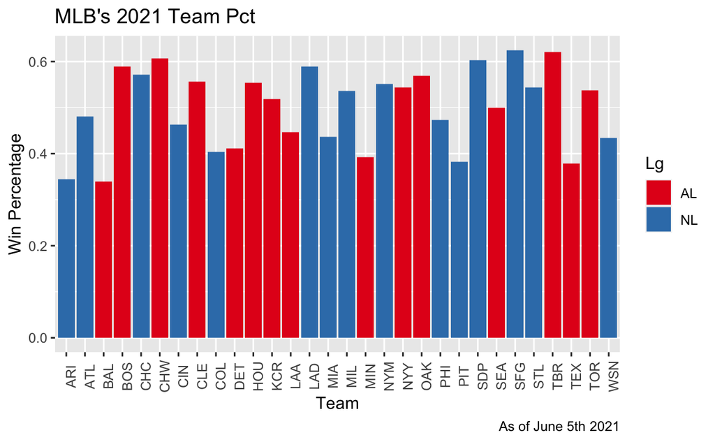

```r
wpg <-
  szn21 %>%
  ggplot(aes(x= Tm, y= Pct, fill = Lg)) +
  geom_bar(stat = 'identity') +
  theme(axis.text.x = element_text(angle = 90)) +
  scale_fill_brewer(palette = 'Set1') +
  xlab('Team') +
  ylab('Win Percentage') +
  labs(title = "MLB's 2021 Team Pct",
       caption = 'As of June 5th 2021')

wpg
```

### What This Means

The graph displayed above highlights each teams win percentage thus far in the season. It can be seen that of the teams in the National League (NL), the San Francisco Giants, San Diego Padres, and the Los Angeles Dodgers have the highest percentages. Meanwhile in the American League (AL) the teams with the highest percentages are the Tampa Bay Rays, Chicago White Sox, and Boston Red Sox. This graph and statistics can make it appear as if these are the best teams in the MLB, which to some extent is true, that isn’t the full story. For example in 2019 the Washington Nationals had an overall Pct of 0.574, but still won the World Series.

This shows that are many factors that play into how well a team performs during the season, such as their strength of schedule.

## Strength of Schedule

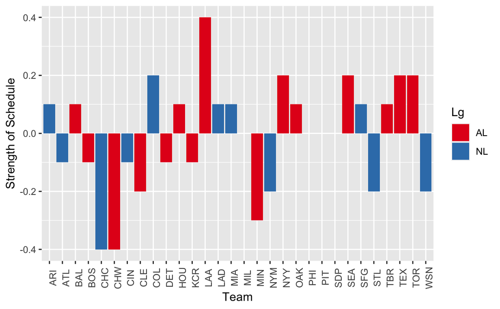

```r
sosg <-
  szn21 %>%
  ggplot(aes(x= Tm, y= SOS, fill = Lg)) +
  geom_bar(stat = 'identity') +
  theme(axis.text.x = element_text(angle = 90)) +
  scale_fill_brewer(palette = 'Set1') +
  xlab('Team') +
  ylab('Strength of Schedule')

sosg
```

### What This Means

This graph displays each teams strength of schedule (SOS) during the 2021 season. The SOS statistic is a constant through all major league sports and evaluates the competitiveness of a teams opponents throughout the season. When the SOS is positive, that means the opponents a team will be facing that season are more difficult. Yet, when a teams is negative, that indicates that their opponents will be less skilled than them. If a team has a SOS of zero, that means that their opponents that season are evenly skilled.

## Win & Loss Margins

Another way to further examine how well a team is performing is by examining their loss and win margins. These numbers detail how many runs a team won or lost by. This is important because it can help to further differentiate lucky teams from the good teams.

Here we will be looking at data from the Washington Nationals 2019 season. We will be looking at this data because this was the last 162 game season we have available and the Nationals won the World Series that year.

```r
nats19 <- read_csv('nats pct 2019 table.csv')  #importing the data
nats19
```

| Rk | Gtm | Date | Opp | Rslt | BA | Opp. Starter (GmeSc) |
| --- | --- | --- | --- | --- | --- | --- |
| 1 | 1 | Mar 28 | NYM | L0-2 | 0.161 | J.deGrom(71) |
| 2 | 2 | Mar 30 | NYM | L8-11 | 0.209 | N.Syndergaard(49) |
| 3 | 3 | Mar 31 | NYM | W6-5 | 0.243 | Z.Wheeler(45) |
| 4 | 4 | Apr 2 | PHI | L2-8 | 0.235 | Z.Eflin(69) |
| 5 | 5 | Apr 3 | PHI | W9-8 | 0.257 | A.Nola(25) |
| 6 | 6 | Apr 4 | NYM | W4-0 | 0.244 | N.Syndergaard(66) |
| 7 | 7 | Apr 6 | NYM | L5-6 | 0.240 | S.Matz(67) |
| 8 | 8 | Apr 7 | NYM | W12-9 | 0.242 | Z.Wheeler(23) |
| 9 | 9 | Apr 8 | PHI | L3-4 | 0.238 | V.Velasquez(53) |
| 10 | 10 | Apr 9 | PHI | W10-6 | 0.250 | A.Nola(43) |

[output cut: 152 more lines]

```r
losses <-  ##filtering the games when the team lost this season
  nats19 %>%
  filter(grepl('^L', Rslt))

losses$Rslt <-   ##removing the L from Rslt column
  gsub('L', '', as.character(losses$Rslt))

losses
```

| Rk | Gtm | Date | Opp | Rslt | BA | Opp. Starter (GmeSc) |
| --- | --- | --- | --- | --- | --- | --- |
| 1 | 1 | Mar 28 | NYM | 0-2 | 0.161 | J.deGrom(71) |
| 2 | 2 | Mar 30 | NYM | 8-11 | 0.209 | N.Syndergaard(49) |
| 4 | 4 | Apr 2 | PHI | 2-8 | 0.235 | Z.Eflin(69) |
| 7 | 7 | Apr 6 | NYM | 5-6 | 0.240 | S.Matz(67) |
| 9 | 9 | Apr 8 | PHI | 3-4 | 0.238 | V.Velasquez(53) |
| 12 | 12 | Apr 12 | PIT | 3-6 | 0.260 | T.Williams(57) |
| 14 | 14 | Apr 14 | PIT | 3-4 | 0.260 | J.Taillon(49) |
| 15 | 15 | Apr 16 | SFG | 3-7 | 0.259 | D.Rodriguez(56) |
| 18 | 18 | Apr 19 | MIA | 2-3 | 0.260 | C.Smith(66) |
| 19 | 19 | Apr 20 | MIA | 3-9 | 0.261 | J.Urena(49) |

[output cut: 59 more lines]

```r
y <- losses$Rslt

LossT <-
  losses %>%   ##creating a margin column based on how badly the team lost
  mutate(LMargin = sapply(y, function(txt) eval(parse(text=txt))))

LossT
```

| Rk | Gtm | Date | Opp | Rslt | BA | Opp. Starter (GmeSc) | LMargin |
| --- | --- | --- | --- | --- | --- | --- | --- |
| 1 | 1 | Mar 28 | NYM | 0-2 | 0.161 | J.deGrom(71) | -2 |
| 2 | 2 | Mar 30 | NYM | 8-11 | 0.209 | N.Syndergaard(49) | -3 |
| 4 | 4 | Apr 2 | PHI | 2-8 | 0.235 | Z.Eflin(69) | -6 |
| 7 | 7 | Apr 6 | NYM | 5-6 | 0.240 | S.Matz(67) | -1 |
| 9 | 9 | Apr 8 | PHI | 3-4 | 0.238 | V.Velasquez(53) | -1 |
| 12 | 12 | Apr 12 | PIT | 3-6 | 0.260 | T.Williams(57) | -3 |
| 14 | 14 | Apr 14 | PIT | 3-4 | 0.260 | J.Taillon(49) | -1 |
| 15 | 15 | Apr 16 | SFG | 3-7 | 0.259 | D.Rodriguez(56) | -4 |
| 18 | 18 | Apr 19 | MIA | 2-3 | 0.260 | C.Smith(66) | -1 |
| 19 | 19 | Apr 20 | MIA | 3-9 | 0.261 | J.Urena(49) | -6 |

[output cut: 59 more lines]

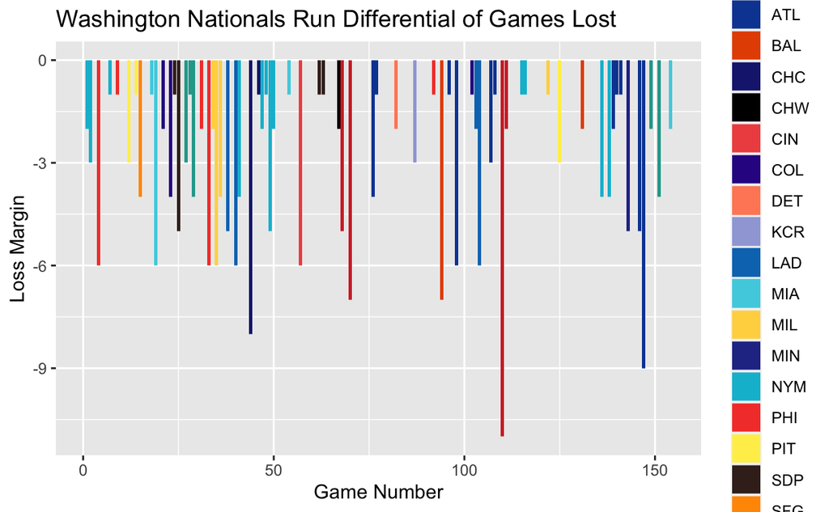

```r
LM <-  ##creating the graph
  LossT %>%
  ggplot(aes(x = Rk, y = LMargin, fill = Opp)) +
  geom_bar(stat = 'identity') +  ##bar graph
  xlab('Game Number') +  ##labels
  ylab('Loss Margin') +
  labs(title = 'Washington Nationals Run Differential of Games Lost') +
  scale_fill_manual(values = c('ATL' = '#0D47A1',
                               'ARI' = '#D32F2F',
                               'BAL' = '#E65100',
                               'CHC' = '#1A237E',
                               'CHW' = 'black',
                               'CIN' = '#EF5350',
                               'CLE' = '#1E88E5',
                               'COL' = '#311B92',
                               'DET' = '#FF8A65',
                               'KCR' = '#9FA8DA',
                               'LAD'= '#0277BD',
                               'MIA'= '#4DD0E1',
                               'MIL'= '#FFD54F',
                               'MIN'= '#283593',
                               'NYM' = '#00BCD4',
                               'PHI'= '#F44336',
                               'PIT'= '#FFEE58',
                               'SDP' = '#3E2723',
                               'SFG'= '#FF9800',
                               'STL'= '#26A69A'
                               ))

LM
```

This graph displays each game the team lost that season and how many runs they lost by. The different colors are associated with what team they lost to.

## Win Margin

```r
wins <-  ##filtering the wins from the nats19 table
  nats19 %>%
  filter(grepl('^W', Rslt))

wins
```

| Rk | Gtm | Date | Opp | Rslt | BA | Opp. Starter (GmeSc) |
| --- | --- | --- | --- | --- | --- | --- |
| 3 | 3 | Mar 31 | NYM | W6-5 | 0.243 | Z.Wheeler(45) |
| 5 | 5 | Apr 3 | PHI | W9-8 | 0.257 | A.Nola(25) |
| 6 | 6 | Apr 4 | NYM | W4-0 | 0.244 | N.Syndergaard(66) |
| 8 | 8 | Apr 7 | NYM | W12-9 | 0.242 | Z.Wheeler(23) |
| 10 | 10 | Apr 9 | PHI | W10-6 | 0.250 | A.Nola(43) |
| 11 | 11 | Apr 10 | PHI | W15-1 | 0.266 | N.Pivetta(22) |
| 13 | 13 | Apr 13 | PIT | W3-2 | 0.257 | C.Archer(72) |
| 16 | 16 | Apr 17 | SFG | W9-6 | 0.264 | J.Samardzija(46) |
| 17 | 17 | Apr 18 | SFG | W4-2 | 0.264 | D.Pomeranz(40) |
| 20 | 20 | Apr 21 | MIA | W5-0 | 0.262 | T.Richards(54) |

[output cut: 83 more lines]

```r
wins$Rslt <-
  gsub('W', '', as.character(wins$Rslt))  ##removing the W from Rslt column

x <- wins$Rslt

winT <-   ##creating the win margin column
  wins%>%
  mutate(WMargin = sapply(x, function(txt) eval(parse(text=txt))))

winT
```

| Rk | Gtm | Date | Opp | Rslt | BA | Opp. Starter (GmeSc) | WMargin |
| --- | --- | --- | --- | --- | --- | --- | --- |
| 3 | 3 | Mar 31 | NYM | 6-5 | 0.243 | Z.Wheeler(45) | 1 |
| 5 | 5 | Apr 3 | PHI | 9-8 | 0.257 | A.Nola(25) | 1 |
| 6 | 6 | Apr 4 | NYM | 4-0 | 0.244 | N.Syndergaard(66) | 4 |
| 8 | 8 | Apr 7 | NYM | 12-9 | 0.242 | Z.Wheeler(23) | 3 |
| 10 | 10 | Apr 9 | PHI | 10-6 | 0.250 | A.Nola(43) | 4 |
| 11 | 11 | Apr 10 | PHI | 15-1 | 0.266 | N.Pivetta(22) | 14 |
| 13 | 13 | Apr 13 | PIT | 3-2 | 0.257 | C.Archer(72) | 1 |
| 16 | 16 | Apr 17 | SFG | 9-6 | 0.264 | J.Samardzija(46) | 3 |
| 17 | 17 | Apr 18 | SFG | 4-2 | 0.264 | D.Pomeranz(40) | 2 |
| 20 | 20 | Apr 21 | MIA | 5-0 | 0.262 | T.Richards(54) | 5 |

[output cut: 83 more lines]

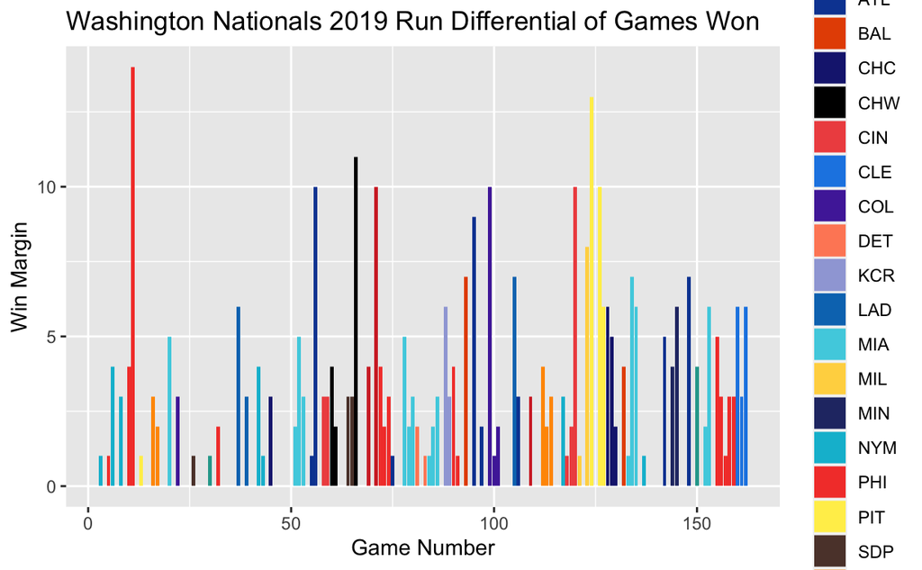

```r
wmgr <-  ##win margin graph
  winT %>%
  ggplot(aes(x= Gtm, y= WMargin, fill = Opp)) +
  geom_bar(stat = 'identity') +
  xlab('Game Number') +
  ylab('Win Margin') +
  labs(title = 'Washington Nationals 2019 Run Differential of Games Won') +
  scale_fill_manual(values = c('ATL' = '#0D47A1',
                               'ARI' = '#D32F2F',
                               'BAL' = '#E65100',
                               'CHC' = '#1A237E',
                               'CHW' = 'black',
                               'CIN' = '#EF5350',
                               'CLE' = '#1E88E5',
                               'COL' = '#512DA8',
                               'DET' = '#FF8A65',
                               'KCR' = '#9FA8DA',
                               'LAD'= '#0277BD',
                               'MIA'= '#4DD0E1',
                               'MIL'= '#FFD54F',
                               'MIN'= '#283573',
                               'NYM' = '#00BCD4',
                               'PHI'= '#F44336',
                               'PIT'= '#FFEE58',
                               'SDP' = '#5d4037',
                               'SFG'= '#FF9800',
                               'STL'= '#26A69A'
                               ))

wmgr
```

This graph displays each game the Nationals won during the 2019 season and by how many runs they won by. Similar to the previous graph the color of the bar is determined by what team they played during that game.